# IGES Educational Workshop Tutorial: Constructing & Evaluating PRS

Maizy Brasher, Chris Arehart, Meng Lin, & Iain Konigsberg

Updated: 2024-10-30

This RMarkdown document contains code demonstrating how to: 1. generate polygenic risk scores (PRS) through clumping & thresholding (C+T).  
2. Calculate and evaluate existing PRS.

> C+T code in Part I is adapted from the excellent [tutorial from bigsnpr author Florian Prive](https://privefl.github.io/bigsnpr/articles/SCT.html)

# Requirements for Tutorial

This tutorial relies on R packages (aside from one optional section).

## R/RStudio

R can be downloaded for [Windows](https://cran.r-project.org/bin/windows/base/), [Mac](https://cran.r-project.org/bin/macosx/), and [Linux](https://cran.r-project.org/).

[RStudio](https://posit.co/download/rstudio-desktop/) is also available for these platforms. Users may want to download RStudio in addition to R because it provides a user-friendly integrated development environment (IDE) with features like syntax highlighting, project management, and advanced visualization tools.

## R Packages

R is an open-source programming language, meaning its source code is freely available for anyone to use and modify. This openness has led to a rich ecosystem of R packages—collections of functions, data, and documentation that extend R’s capabilities for tasks like genomics analysis, data visualization, and machine learning. Users can install and load these packages from repositories like CRAN (Comprehensive R Archive Network) to enhance R’s functionality.

# Part I: Generating PRS Weights from GWAS Data

#### Goal:

Use GWAS summary statistics to calculate PRS for individuals in a 1000 Genomes sample.

## Input Files

Summary statistics were downloaded from the [GIANT consortium](https://portals.broadinstitute.org/collaboration/giant/index.php/GIANT_consortium_data_files).

1000 Genomes Project sample information was obtained from the [1000 Genomes Portal](https://www.internationalgenome.org/data-portal/sample)

1000 Genomes Project genotypes were obtained from the [1000 Genomes FTP site](https://ftp.1000genomes.ebi.ac.uk/vol1/ftp/). Genotypes were subset to common chromosome 9 variants present in the summary statistics file.

> Uncomment the lines below if any R packages are not installed:

```r
# Install required packages

#install.packages("data.table")
#install.packages("bigsnpr")
#install.packages("devtools")
#devtools::install_github("kaustubhad/fastman")
#install.packages("dplyr")
#install.packages("tidyr")
#install.packages("ggplot2")
#install.packages("ggpubr")
#install.packages("GGally")
#install.packages("pROC")



# Load required libraries

library(data.table) #fast file i/o
library(bigsnpr) #genetic data & PRS construction
library(fastman) #fast manhattan plotting
library(dplyr) #data frame manipulation
library(tidyr) #data frame manipulation
library(ggplot2) #plotting
library(ggpubr) #adding statistics to plots
library(GGally) #pairwise plotting
library(pROC) #auc calculation

# Set ggplot2 theme for cleaner plots
theme_set(theme_bw())
```

### Summary Statistics

Here, we load the summary statistics from the GIANT study and focus on chromosome 9. A Manhattan plot is generated to visualize the variant p-values.

```r
# Read in GIANT summary statistics
sumstats <- fread("GIANT_HEIGHT_YENGO_2022_GWAS_SUMMARY_STATS_EUR", data.table = FALSE)

# View the first few rows
head(sumstats)
```

|  | SNPID | RSID | CHR | POS | EFFECT_ALLELE | OTHER_ALLELE | EFFECT_ALLELE_FREQ | BETA | SE | P | N |
| --- | --- | --- | --- | --- | --- | --- | --- | --- | --- | --- | --- |
| 1 | 1:566875:C:T | rs2185539 | 1 | 566875 | T | C | 0.002800 | -0.046315600 | 0.03930 | 0.238128 | 537968 |
| 2 | 1:728951:C:T | rs11240767 | 1 | 728951 | T | C | 0.000356 | 0.167358000 | 0.12600 | 0.185025 | 85591 |
| 3 | 1:734462:A:G | rs12564807 | 1 | 734462 | A | G | 0.893000 | 0.004656900 | 0.01100 | 0.672866 | 112953 |
| 4 | 1:752721:A:G | rs3131972 | 1 | 752721 | G | A | 0.840000 | 0.000544089 | 0.00284 | 0.84811 | 615932 |
| 5 | 1:754182:A:G | rs3131969 | 1 | 754182 | G | A | 0.865000 | 0.001333110 | 0.00185 | 0.470389 | 1100634 |
| 6 | 1:754334:C:T | rs3131967 | 1 | 754334 | C | T | 0.866000 | 0.001429190 | 0.00185 | 0.440485 | 1095682 |

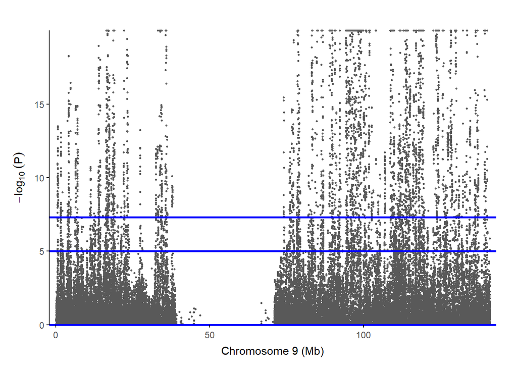

```r
# Subset to chromosome 9
sumstats <- sumstats[sumstats$CHR == 9, ]

# Convert p-values to numeric for plotting
sumstats$P <- as.numeric(sumstats$P)

# Manhattan plot of chromosome 9 summary statistics
fastman_gg(sumstats, bp = "POS", maxP = 20, suggestiveline = NA, genomewideline = NA, col = "greys") +
  geom_hline(yintercept = -log10(5e-8), color = "blue", linewidth = 1) +   # Genome-wide significance threshold
  geom_hline(yintercept = -log10(1e-5), color = "blue", linewidth = 1) +    # Suggestive significance threshold
  geom_hline(yintercept = -log10(1), color = "blue", linewidth = 1)
```

```r
# Summary statistics overview
cat("Total variants: ", nrow(sumstats))
```

```
## Total variants:  63048
```

```r
cat("Variants with p <= 1e-5: ", nrow(sumstats[sumstats$P <= 1e-5, ]))
```

```
## Variants with p <= 1e-5:  8176
```

```r
cat("Variants with p <= 5e-8: ", nrow(sumstats[sumstats$P <= 5e-8, ]))
```

```
## Variants with p <= 5e-8:  5821
```

### 1000 Genomes Samples

We now load and inspect the sample information from the 1000 Genomes Project.

```r
# Load 1000 Genomes sample information
pd <- fread("all_simulated_table_v2.txt", data.table = FALSE)

# Total samples and super population counts
cat("Total samples: ", nrow(pd))
```

```
## Total samples:  2548
```

```r
table(pd$`Super_Population`)
```

```
##
## AFR AMR EAS EUR SAS
## 671 348 515 522 492
```

### Genotype Data

Next, we load the genetic data formatted for bigsnpr and inspect its structure.

```r
# Load bigsnpr-formatted genetic data for European and pooled samples
eur <- snp_attach("chr9_eur.rds")
pooled <- snp_attach("chr9_pooled.rds")

# Inspect the genotype data structure
names(pooled)
```

```
## [1] "genotypes" "fam"       "map"
```

```r
head(pooled$genotypes)[,1:10]
```

```
##      [,1] [,2] [,3] [,4] [,5] [,6] [,7] [,8] [,9] [,10]
## [1,]    0    0    0    1    1    1    1    2    1     1
## [2,]    0    0    1    2    2    0    0    1    0     0
## [3,]    0    0    0    2    2    2    2    2    2     2
## [4,]    1    1    1    2    2    0    0    0    0     0
## [5,]    0    0    0    1    1    1    1    2    1     1
## [6,]    1    2    0    2    2    0    0    1    0     0
```

```r
head(pooled$fam)
```

|  | family.ID | sample.ID | paternal.ID | maternal.ID | sex | affection |
| --- | --- | --- | --- | --- | --- | --- |
| 1 | 0 | HG00096 | 0 | 0 | 0 | -9 |
| 2 | 0 | HG00097 | 0 | 0 | 0 | -9 |
| 3 | 0 | HG00099 | 0 | 0 | 0 | -9 |
| 4 | 0 | HG00100 | 0 | 0 | 0 | -9 |
| 5 | 0 | HG00101 | 0 | 0 | 0 | -9 |
| 6 | 0 | HG00102 | 0 | 0 | 0 | -9 |

```r
head(pooled$map)
```

|  | chromosome | marker.ID | genetic.dist | physical.pos | allele1 | allele2 |
| --- | --- | --- | --- | --- | --- | --- |
| 1 | 9 | . | 0 | 40910 | G | T |
| 2 | 9 | . | 0 | 46587 | T | C |
| 3 | 9 | . | 0 | 101857 | A | G |
| 4 | 9 | . | 0 | 191843 | A | G |
| 5 | 9 | . | 0 | 192129 | A | T |
| 6 | 9 | . | 0 | 203310 | C | A |

## Clumping & Thresholding

### Matching Genotypes w/ Sumstats

In this step, we match the summary statistics and genotype data, ensuring that the variant names and effect alleles align.

```r
# Subset and rename columns in summary statistics
sumstats <- sumstats %>% select(CHR, RSID, POS, EFFECT_ALLELE, OTHER_ALLELE, BETA, P)
names(sumstats) <- c("chr", "rsid", "pos", "a0", "a1", "beta", "p")

# Prepare genotype map by removing unnecessary columns
map <- eur$map[,-(2:3)]
names(map) <- c("chr", "pos", "a0", "a1")

# Match variants between summary statistics and genotypes
info_snp <- snp_match(sumstats, map)
```

```
## 63,048 variants to be matched.
```

```
## 1,092 ambiguous SNPs have been removed.
```

```
## 8,624 variants have been matched; 52 were flipped and 193 were reversed.
```

### Clumping

```r
# Prepare variables for clumping
info_snp$p <- as.numeric(info_snp$p)
beta <- rep(NA, ncol(eur$genotypes))
beta[info_snp$`_NUM_ID_`] <- info_snp$beta
lpval <- rep(NA, ncol(eur$genotypes))
lpval[info_snp$`_NUM_ID_`] <- -log10(info_snp$p)

# Perform clumping
clumped_snps <- snp_grid_clumping(pooled$genotypes, eur$map$chromosome, eur$map$physical.pos, lpS = lpval, exclude = which(is.na(lpval)), grid.thr.r2 = 0.1, grid.base.size = 250)

# Report the number of independent SNPs
cat("Number of independent SNPs retained: ", length(clumped_snps[[1]][[1]]))
```

```
## Number of independent SNPs retained:  1381
```

### Thresholding

In this section, we apply different p-value thresholds to generate multiple PRS.

```r
# Generate PRS at different p-value thresholds
prs_object <- snp_grid_PRS(pooled$genotypes, clumped_snps, beta, lpval,
                          grid.lpS.thr = c(-log10(5e-8), -log10(1e-5), -log10(1)))

# Extract scores for each threshold
scores <- as.data.frame(prs_object[,1:3])
scores <- as.data.frame(cbind(pooled$fam$sample.ID, scores))
names(scores) <- c("IID", "mod_sig", "mod_sug", "mod_inf")


# Save the scores
write.csv(scores, "scores.csv", row.names = FALSE)

# Merge scores with sample information
res <- merge(pd, scores, by = "IID")
```

## Visualizing Results

### Correlation Between Scores

We start by exploring the correlations between the PRS at different p-value thresholds.

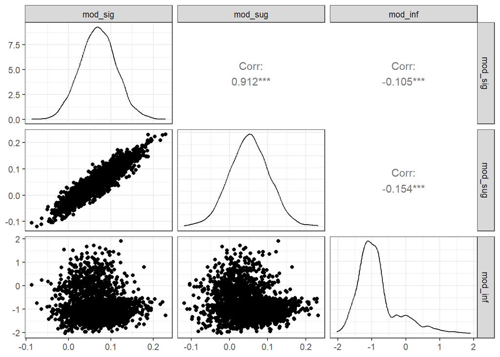

```r
# Pairwise correlations between scores
ggpairs(res[ , c("mod_sig", "mod_sug", "mod_inf")])
```

### Score Distributions

Next, we visualize the distribution of scores by population.

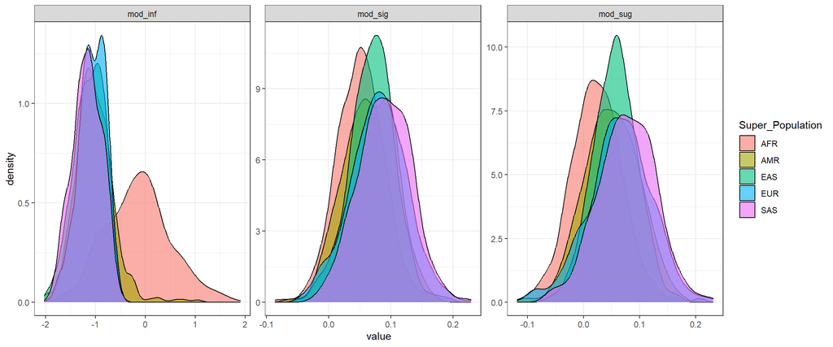

```r
# Visualize score distributions across populations
res %>%
  pivot_longer(cols = c(mod_sig:mod_inf)) %>%
  ggplot(aes(value, fill = Super_Population)) +
    geom_density(alpha = 0.6) +
    facet_wrap(~name, scales = "free")
```

### Performance by *p* Threshold

Finally, we assess the performance of the PRS models by comparing incremental R*2* values at different thresholds.

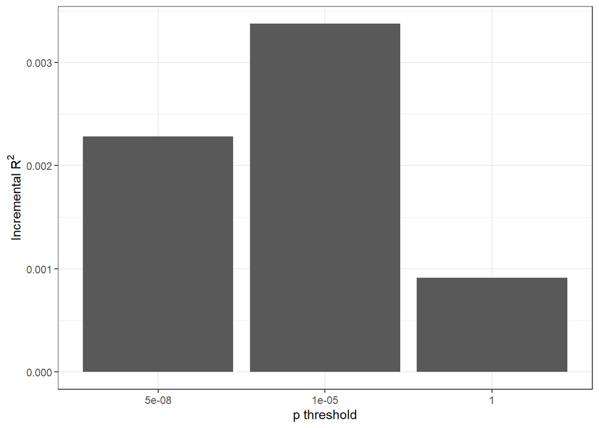

```r
# Create simulated height variable
res$sim_height <- res$sim_pheno_quant * 4 + 168

# Fit model with covariates using each score
mod_base <- lm(sim_height ~ sex + sim_age + PC1 + PC2 + PC3 + PC4 + PC5, data = res)
mod_1 <- lm(sim_height ~ mod_sig + sex + sim_age + PC1 + PC2 + PC3 + PC4 + PC5, data = res)
mod_2 <- lm(sim_height ~ mod_sug + sex + sim_age + PC1 + PC2 + PC3 + PC4 + PC5, data = res)
mod_3 <- lm(sim_height ~ mod_inf + sex + sim_age + PC1 + PC2 + PC3 + PC4 + PC5, data = res)

# Calculate r2 of base model
r2_base <- summary(mod_base)$r.squared

# Calculate r2 of models with PRS
r2_sig <- summary(mod_1)$r.squared
r2_sug <- summary(mod_2)$r.squared
r2_inf <- summary(mod_3)$r.squared

# Define p-value thresholds and calculate r^2s
mods <- c(5e-8, 1e-5, 1)

# Calculate incremental R^2s
incs <- c(r2_sig - r2_base,
          r2_sug - r2_base,
          r2_inf - r2_base)

# Create performance dataframe and plot results
df <- as.data.frame(cbind(mods, incs))

ggplot(df, aes(as.factor(mods), incs)) +
  geom_bar(stat = "identity") +
  labs(y = expression("Incremental " * R^2), x = "p threshold")
```

### Genetic Similarity (PCs)

In this section, we explore the genetic similarity of individuals by visualizing principal components (PCs) and computing the genetic distance from the European population (EUR) center. This approach allows us to assess the distribution of polygenic risk scores across populations based on their genetic similarity.

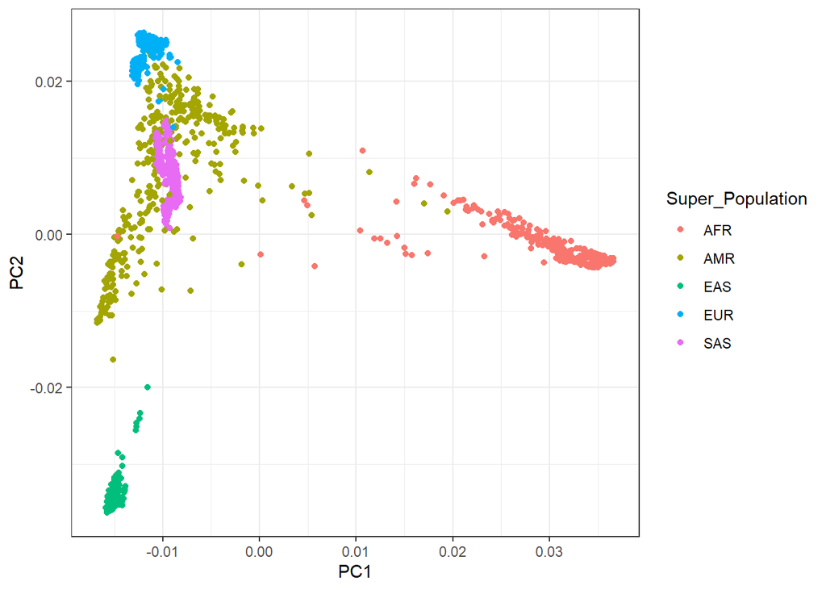

```r
# Plot PC1 vs PC2 colored by Super Population
ggplot(res, aes(PC1, PC2, color = Super_Population)) + geom_point()
```

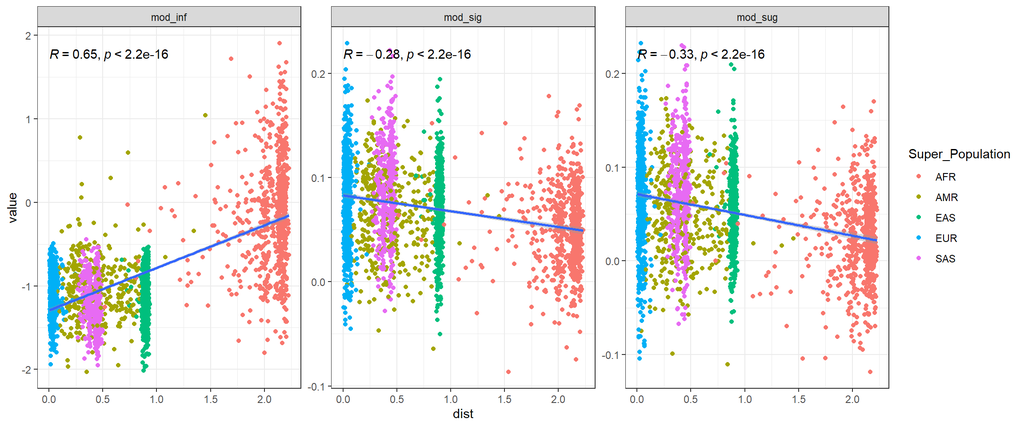

```r
# Speciyfy eigenvalues for the principal components
vals <- c(45, 15, 6.1, 4.4, 3.9)

# Weight PCs by variance explained
res <- res %>% mutate(across(PC1:PC4, ~ . * vals[as.numeric(gsub("PC", "", cur_column()))]))

# Define the median value for the first 5 PCs in the European population
center1 <- median(res[res$Super_Population == "EUR", ]$PC1)
center2 <- median(res[res$Super_Population == "EUR", ]$PC2)
center3 <- median(res[res$Super_Population == "EUR", ]$PC3)
center4 <- median(res[res$Super_Population == "EUR", ]$PC4)
center5 <- median(res[res$Super_Population == "EUR", ]$PC5)

# Calculate the genetic distance of each sample from the EUR median
res$dist <- sqrt((res$PC1 - center1)^2 + (res$PC2 - center2)^2 + (res$PC3 - center3)^2 + (res$PC4 - center4)^2 + (res$PC5 - center5)^2)

# Plot scores against genetic distance from EUR center
res %>%
  pivot_longer(cols = c(mod_sig:mod_inf)) %>%
  ggplot(aes(dist, value)) +
    geom_point(aes(color = Super_Population)) +
    facet_wrap(~name, scales = "free") +
    geom_smooth(method = "lm") +
    stat_cor()
```

# Part II: Calculation and Evaluation of PRS

#### Goal:

See how to use the PRS weights derived in Part I to calculate scores for individuals in a 1000 Genomes sample. Then evaluate and compare the performance of multiple scores across diverse ancestry groups.

#### Requirements for this tutorial:

1. Download [workshop materials](https://github.com/konigsbergi/iges-workshop-2024)
   - genotype data files
   - phenotype data file (phenotype, populations, scores, and covariates)
2. PRS from session 1
3. (Optional) Terminal access for running ESCALATOR pipeline

#### Description of provided files:

- genetic file names (only needed for optional PRS calculation) = chr9_all_1000g.tar.gz: Due to the file size limit, you may download from the Onedrive location [here](https://olucdenver-my.sharepoint.com/:u:/g/personal/meng_lin_cuanschutz_edu/EVv7beNqc3lBgK-ajNoXBZkBAGDB0VEyrZhlUHzZJZ601Q) (compressed [PLINK2 binary format](https://www.cog-genomics.org/plink/2.0/input#pgen) )
- phenotype file name = all_simulated_table_v2.txt
  - IID = unique ID for each individual
  - Population = specific 1000 Genomes population ancestry group (ex. GBR = Great Britain)
  - Super_Population = broader continental ancestry group (ex. EAS = East Asia)
  - sex = males (1) or females (2) as provided by 1000 genomes
  - sim_age = simulated age variable for use as a covariate
  - PC 1-5 = genetic principal components calculated from the 1000 genomes individuals
  - sim_pheno_dict = simulated binary phenotype with cases (1) and controls (0)
  - sim_pheno_quant = simulated quantitative phenotype
  - score 1-3 = chr9 PRS from the PRS catalog (PGS002993, PGS004213, & PGS003838)
- scores from session 1 - scores.csv
  - mod_sig = score calculated in session 1 using genome-wide significant threshold (5e-8)
  - mod_sug = score calculated in session 1 using genome-wide suggestive threshold (1e-5)
  - mod_inf = score calculated in session 1 using all SNPs (p-value threshold of 1)

```r
# Install packages if not installed
#install.packages("ggplot2")
library(ggplot2) #plotting

#install.packages("data.table")
library(data.table) #file i/o

#install.packages("dplyr")
library(dplyr) #dataframe manipulation

#install.packages("patchwork")
library(patchwork) #arranging multiple plots

#install.packages("pROC")
library(pROC) #AUC calculations and plotting
```

## PRS Calculation (Optional)

This section demonstrates one method for calculating PRS from weight files downloaded from the PRS catalog. In this section, we will use the containerized [ESCALATOR pipeline](https://github.com/menglin44/escalator) for score harmonization and calculation. More details and examples can be found in the GitHub repository.

### Download example data and weight file

Use terminal commands to decompress the example PLINK2 file, and to download an example weight file from the [PGS Catalog](https://www.pgscatalog.org/):

```bash
### In the directory you plan to run the pipeline
## decompress genetic file
tar -xzvf chr9_all_1000g.tar.gz

## download weight
# For Linux:
wget https://ftp.ebi.ac.uk/pub/databases/spot/pgs/scores/PGS002993/ScoringFiles/Harmonized/PGS002993_hmPOS_GRCh38.txt.gz

# For macOS:
curl -O https://ftp.ebi.ac.uk/pub/databases/spot/pgs/scores/PGS002993/ScoringFiles/Harmonized/PGS002993_hmPOS_GRCh38.txt.gz
```

### Configure ESCALATOR

For *Mac* users, make sure that [Docker Desktop](https://www.docker.com/products/docker-desktop/) is installed and running. Then pull the image with:

```r
docker pull mfisher126/escalator:M_macbook_v4
```

Other platform users (e.g. *Linux*) can use *singularity* image - make sure [singularity](https://docs.sylabs.io/guides/3.5/user-guide/introduction.html) is installed and works properly. Then, you can download the image manually from [here](https://olucdenver-my.sharepoint.com/:u:/g/personal/meng_lin_cuanschutz_edu/EQ8IM0p0itZHgKGqKge6JY0BVXAovZ66TpeV6waKr100DQ).

Within the current working folder, make a sub-directory to host score outputs:

```r
cd [Your_Main_Working_Directory]
mkdir output
```

> (replace *[Your_Main_Working_Directory]* above with your directory hosting the files)

To run the pipeline, *Mac* users can try

```r
docker run -v /Your_Main_Working_Directory:/data \
-it mfisher126/escalator:M_macbook_v4 \
masterPRS_v4.sh 3 \
/data PGS002993_hmPOS_GRCh38.txt.gz \
/data/output/ height_chr9 \
/data/chr9_all_1000g all_1000g \
T NA
```

> (replace */Your_Main_Working_Directory* above with your directory hosting the files)

Alternatively, Linux users can use the singularity image -

```r
singularity exec escalator-v2.sif masterPRS_v4.sh 3 \
/Your_Main_Working_Directory/ \
PGS002993_hmPOS_GRCh38.txt.gz \
/Your_Main_Working_Directory/output/ \
height1_chr9 \
/Your_Main_Working_direcrtory/chr9_all_1000g/ \
all_1000g \
T \
NA
```

> (replace */Your_Main_Working_Directory* above with your directory hosting the files)

> **Note**: We are only using chromosome 9 for an example run. In reality, you can have complete genetic data of all autosomes parsed into each chromosome per file, named with prefixes as *chr*_all_1000g* , the command above still works and will automatically search for each chromosome.

> For complete information on the pipeline usage and explanations, please refer to [this page](https://github.com/menglin44/escalator).

When finished, you’ll see summary information on the screen like this:

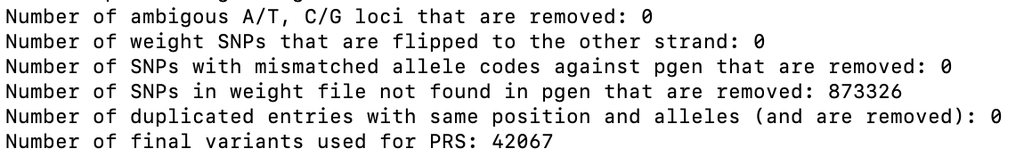

Inside the ~output folder, you expect to see an output file named *height1_chr9_prs.sscore* , which would be the calculated score.

## PRS Evaluation

For the purposes of this tutorial, we have calculated PRS from three PGS catalog scores for you. We also have the three scores that were calculated in Part 1 of this tutorial. In this section, we will demonstrate some methods for evaluating and comparing scores.

### Read in Phenotype and Scores

```r
# Load phenotype data
data <- fread("all_simulated_table_v2.txt", data.table = FALSE)
head(data)
```

|  | IID | Population | Super_Population | sex | sim_age | PC1 | PC2 | PC3 | PC4 | PC5 | sim_pheno_dict | sim_pheno_quant | score1 | score2 | score3 |
| --- | --- | --- | --- | --- | --- | --- | --- | --- | --- | --- | --- | --- | --- | --- | --- |
| 1 | HG00096 | GBR | EUR | 1 | 74 | -0.0119648 | 0.0254377 | 0.00794150 | -0.0210734 | -0.001845140 | 0 | -1.1246832 | -0.11018357 | -0.7463962 | -2.390886 |
| 2 | HG00097 | GBR | EUR | 2 | 52 | -0.0122562 | 0.0256272 | 0.00785074 | -0.0214233 | -0.001069640 | 0 | 0.2329595 | 0.01690244 | -0.7254322 | -2.046554 |
| 3 | HG00099 | GBR | EUR | 2 | 58 | -0.0123227 | 0.0254436 | 0.00779781 | -0.0207617 | -0.000958936 | 0 | 0.6181552 | 0.04008304 | -0.7294641 | -1.851095 |
| 4 | HG00100 | GBR | EUR | 2 | 54 | -0.0120538 | 0.0259843 | 0.00751506 | -0.0217761 | -0.003207370 | 0 | -0.7059269 | -0.18870078 | -0.8504537 | -2.880764 |
| 5 | HG00101 | GBR | EUR | 1 | 42 | -0.0122382 | 0.0256484 | 0.00835984 | -0.0218173 | -0.003118810 | 0 | 0.2100667 | -0.07520461 | -0.6634385 | -1.638944 |
| 6 | HG00102 | GBR | EUR | 2 | 36 | -0.0123512 | 0.0255323 | 0.00790186 | -0.0214281 | -0.002594490 | 0 | 0.7652465 | -0.01085303 | -0.7406258 | -2.505849 |

```r
str(data)
```

```
## 'data.frame':    2548 obs. of  15 variables:
##  $ IID             : chr  "HG00096" "HG00097" "HG00099" "HG00100" ...
##  $ Population      : chr  "GBR" "GBR" "GBR" "GBR" ...
##  $ Super_Population: chr  "EUR" "EUR" "EUR" "EUR" ...
##  $ sex             : int  1 2 2 2 1 2 1 2 1 2 ...
##  $ sim_age         : int  74 52 58 54 42 36 25 46 27 51 ...
##  $ PC1             : num  -0.012 -0.0123 -0.0123 -0.0121 -0.0122 ...
##  $ PC2             : num  0.0254 0.0256 0.0254 0.026 0.0256 ...
##  $ PC3             : num  0.00794 0.00785 0.0078 0.00752 0.00836 ...
##  $ PC4             : num  -0.0211 -0.0214 -0.0208 -0.0218 -0.0218 ...
##  $ PC5             : num  -0.001845 -0.00107 -0.000959 -0.003207 -0.003119 ...
##  $ sim_pheno_dict  : int  0 0 0 0 0 0 0 0 0 0 ...
##  $ sim_pheno_quant : num  -1.125 0.233 0.618 -0.706 0.21 ...
##  $ score1          : num  -0.1102 0.0169 0.0401 -0.1887 -0.0752 ...
##  $ score2          : num  -0.746 -0.725 -0.729 -0.85 -0.663 ...
##  $ score3          : num  -2.39 -2.05 -1.85 -2.88 -1.64 ...
```

```r
# Load scores from session 1
scores_new <- fread("scores.csv", data.table = FALSE)
head(scores_new)
```

|  | IID | mod_sig | mod_sug | mod_inf |
| --- | --- | --- | --- | --- |
| 1 | HG00096 | 0.08965786 | 0.09300135 | -1.1559372 |
| 2 | HG00097 | 0.09526619 | 0.07645977 | -1.1080792 |
| 3 | HG00099 | 0.01368556 | 0.00219664 | -0.8226229 |
| 4 | HG00100 | 0.08581208 | 0.09196238 | -1.2626764 |
| 5 | HG00101 | 0.02706289 | -0.01333770 | -0.9107707 |
| 6 | HG00102 | 0.11419715 | 0.09347170 | -1.6161532 |

```r
str(scores_new)
```

```
## 'data.frame':    2547 obs. of  4 variables:
##  $ IID    : chr  "HG00096" "HG00097" "HG00099" "HG00100" ...
##  $ mod_sig: num  0.0897 0.0953 0.0137 0.0858 0.0271 ...
##  $ mod_sug: num  0.093 0.0765 0.0022 0.092 -0.0133 ...
##  $ mod_inf: num  -1.156 -1.108 -0.823 -1.263 -0.911 ...
```

```r
# Merge phenotype and scores
full <- inner_join(data, select(scores_new, all_of(c("IID", "mod_sig", "mod_sug", "mod_inf"))), by = "IID")
colnames(full)[match(c("mod_sig", "mod_sug", "mod_inf"), colnames(full))] <- c("score_sig", "score_sug", "score_inf")
```

### Visualize PRS Distributions

Now we will plot each PRS by simulated phenotype case/control status.

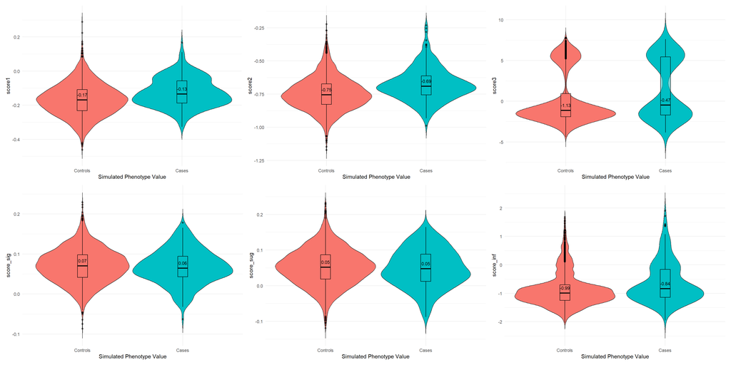

```r
# Create list for plots
plot_list <- list()
scores <- colnames(select(full, contains("score")))

# Plot score distributions between cases and controls
for (score_col in scores) {

  # Create the violin plot
  p <- full %>%
    ggplot(aes(x = as.factor(sim_pheno_dict), y = .data[[score_col]], fill = as.factor(sim_pheno_dict))) +
    geom_violin(trim = FALSE, width = 1) +
    geom_boxplot(width = 0.1, color = "black", alpha = 0.5) +
    theme_minimal() +
    theme(
      legend.position = "none",
      plot.title = element_text(size = 11)
    ) +
    xlab("Simulated Phenotype Value") +
    scale_x_discrete(labels = c("Controls", "Cases")) +
    stat_summary(fun = median, geom = "text", aes(label = round(after_stat(y), 2)),
                 vjust = -1, size = 3, color = "black")  # Add median text

  # Save to the list
  plot_list[[score_col]] <- p
}

# organize the plots
combined_plot <- (plot_list$score1 | plot_list$score2 | plot_list$score3) / (plot_list$score_sig | plot_list$score_sug | plot_list$score_inf)

combined_plot
```

```r
# Save the plot
ggsave("score_distributions_casecontrol.png", width = 20, height = 10)
```

### Calculate AUC and ROC Curves

We calculate the AUC for a simulated binary phenotype in the EUR population and visualize the ROC curves for PRS-only, covariates-only, and full models.

```r
# Define covariates
pcs <- paste("PC", 1:5, sep = "")
covars <- c("sex", "sim_age", pcs)

# Filter to one population
EUR_only <- filter(full, Super_Population == "EUR")

# Standardize score within ancestry group
EUR_only$stand_score1 <- as.numeric(scale(EUR_only$score1, T, T))

# Calculate AUC
# PRS and covariates
glm_all <- glm(as.formula(paste0("sim_pheno_dict ~ stand_score1 + ", paste0(covars, collapse = " + "))), family = "binomial", data = EUR_only)

# PRS only
glm_prs <- glm(as.formula(paste0("sim_pheno_dict ~ stand_score1")), family = "binomial", data = EUR_only)

# covariates only
glm_cov <- glm(as.formula(paste0("sim_pheno_dict ~ ", paste0(covars, collapse = " + "))), family = "binomial", data = EUR_only)

# Get predicted values for each model
prdt_all <- predict(glm_all, type="response")
prdt_prs <- predict(glm_prs, type="response")
prdt_cov <- predict(glm_cov, type="response")

# Build roc curve for each model
roc_all <- roc(EUR_only$sim_pheno_dict, prdt_all, ci=TRUE)
roc_prs <- roc(EUR_only$sim_pheno_dict, prdt_prs, ci=TRUE)
roc_cov <- roc(EUR_only$sim_pheno_dict, prdt_cov, ci=TRUE)
# Get AUC values and confidence intervals for each model
auc_all <- round(as.numeric(roc_all$auc),3)
ci_all <- round(as.numeric(roc_all$ci)[c(1,3)],3)
auc_prs <- round(as.numeric(roc_prs$auc),3)
ci_prs <- round(as.numeric(roc_prs$ci)[c(1,3)],3)
auc_cov <- round(as.numeric(roc_cov$auc),3)
ci_cov <- round(as.numeric(roc_cov$ci)[c(1,3)],3)
```

### Plot ROC Curves

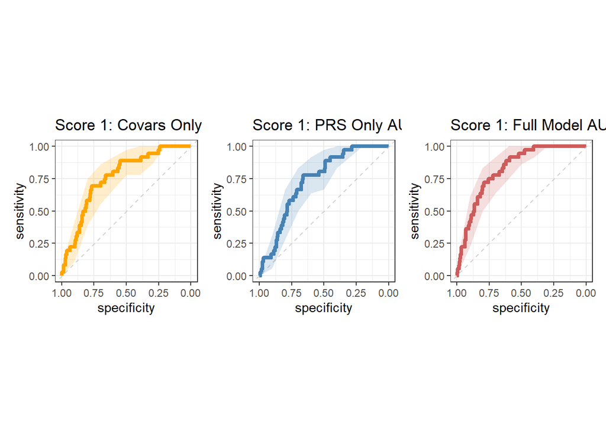

```r
# PRS and covariates
p_all <- ggroc(roc_all, color = "indianred", size = 1.5) +
      ggtitle(paste0("Score 1: Full Model AUC = ", auc_all)) +
      geom_abline(slope = 1, intercept = 1, linetype = "dashed", alpha = 0.7, color = "grey") +
      coord_equal()

# PRS only
p_prs <- ggroc(roc_prs, color = "steelblue", size = 1.5) +
      ggtitle(paste0("Score 1: PRS Only AUC = ", auc_prs)) +
      geom_abline(slope = 1, intercept = 1, linetype = "dashed", alpha = 0.7, color = "grey") +
      coord_equal()

# covariates only
p_cov <- ggroc(roc_cov, color = "orange", size = 1.5) +
    ggtitle(paste0("Score 1: Covars Only AUC = ", auc_cov)) +
      geom_abline(slope=1, intercept = 1, linetype = "dashed", alpha=0.7, color = "grey") +
      coord_equal()

# Get confidence intervals
ciobj_all <- ci.se(roc_all, l = 30)
ciobj_prs <- ci.se(roc_prs, l = 30)
ciobj_cov <- ci.se(roc_cov, l = 30)

dat.ci.all <- data.frame(x=as.numeric(rownames(ciobj_all)),
                               lower = ciobj_all[,1],
                               upper = ciobj_all[,3])
dat.ci.prs <- data.frame(x=as.numeric(rownames(ciobj_prs)),
                               lower = ciobj_prs[,1],
                               upper = ciobj_prs[,3])

dat.ci.cov <- data.frame(x=as.numeric(rownames(ciobj_cov)),
                               lower = ciobj_cov[,1],
                               upper = ciobj_cov[,3])

# add confidence intervals to plots
p_all <- p_all +
        geom_ribbon(data = dat.ci.all, aes(x = x, ymin = lower, ymax = upper), fill = "indianred", alpha = 0.2)

p_prs <- p_prs +
        geom_ribbon(data = dat.ci.prs, aes(x = x, ymin = lower, ymax = upper), fill = "steelblue", alpha = 0.2)

p_cov <- p_cov +
        geom_ribbon(data = dat.ci.cov, aes(x = x, ymin = lower, ymax = upper), fill = "orange", alpha = 0.2)

# save final plots
combined_plot <- p_cov + p_prs + p_all
combined_plot
```

```r
ggsave("example_AUC_roc_EURscore1.png", width = 20, height = 5)
```

### Evaluate AUC Values

We systematically evaluate AUC for all scores across all ancestry groups, as well as calculate incremental AUC. The incremental AUC can be used to isolate the explanatory power of the PRS for the binary target trait. The incremental AUC is calculated by subtracting the covariate-only model AUC from the full model AUC to assess the increase in AUC with the addition of PRS to the model.

```r
#### Evaluate all scores across all populations ####
# Define populations
populations <- levels(as.factor(full$Super_Population))

# Define scores
scores <- colnames(select(full, contains("score")))

# Define output tables
# Saving AUC values
auc_vals <- data.frame(Super_Population = character())

# Incremental AUC values
inc_auc_vals <- data.frame(Super_Population = character())

# Beta values (for use later)
betas <- data.frame(Super_Population = character())

# And p-values (for use later)
p_vals <- data.frame(Super_Population = character())


# Calculate AUC values for each score in each population
for (pop in populations) {
    # filter to one population
    print(paste0("Calculating for scores in population: ", pop))
    pop_only <- filter(full, Super_Population == pop)
    print(paste0("Number of individuals: ", nrow(pop_only)))
    print(paste0("Number of cases: ", nrow(filter(pop_only, sim_pheno_dict == 1))))

    # set up for outputs
    auc_row <- list(Super_Population = pop)
    inc_auc_row <- list(Super_Population = pop)
    beta_row <- list(Super_Population = pop)
    p_val_row <- list(Super_Population = pop)

    for (score in scores) {
        # standardize scores within ancestry group
        print(paste0("Evaluating score: ", score))
        pop_only$stand_score <- as.numeric(scale(pop_only[[score]], T, T))

        # run the models (PRS and covariates, just PRS, just covariates)
        glm_all <- glm(as.formula(paste0("sim_pheno_dict ~ stand_score + ", paste0(covars, collapse = " + "))), family = "binomial", data = pop_only)
        glm_prs <- glm(as.formula(paste0("sim_pheno_dict ~ stand_score")), family = "binomial", data = pop_only)
        glm_cov <- glm(as.formula(paste0("sim_pheno_dict ~ ", paste0(covars, collapse = " + "))), family = "binomial", data = pop_only)

        # get predicted values for each model
        prdt_all <- predict(glm_all, type="response")
        prdt_prs <- predict(glm_prs, type="response")
        prdt_cov <- predict(glm_cov, type="response")

        # build roc curve for each model
        roc_all <- roc(pop_only$sim_pheno_dict, prdt_all, ci=TRUE)
        roc_prs <- roc(pop_only$sim_pheno_dict, prdt_prs, ci=TRUE)
        roc_cov <- roc(pop_only$sim_pheno_dict, prdt_cov, ci=TRUE)

        # get AUC values and confidence intervals for each model
        auc_all <- round(as.numeric(roc_all$auc),3)
        auc_prs <- round(as.numeric(roc_prs$auc),3)
        auc_cov <- round(as.numeric(roc_cov$auc),3)

        # calculate incremental AUC
        inc_auc <- auc_all - auc_cov

        # save values (for this demo only saving full model and incremental AUC)
        auc_row[[score]] <- auc_all
        inc_auc_row[[score]] <- round(inc_auc, 3)

        # save these for later use
        beta_row[[score]] <- coef(summary(glm_all))[2,1]
        p_val_row[[score]] <- coef(summary(glm_all))[2,4]
  }

  auc_vals <- rbind(auc_vals, as.data.frame(auc_row, stringsAsFactors = FALSE))
  inc_auc_vals <- rbind(inc_auc_vals, as.data.frame(inc_auc_row, stringsAsFactors = FALSE))
  betas <- rbind(betas, as.data.frame(beta_row, stringsAsFactors = FALSE))
  p_vals <- rbind(p_vals, as.data.frame(p_val_row, stringsAsFactors = FALSE))
}
```

```
## [1] "Calculating for scores in population: AFR"
## [1] "Number of individuals: 671"
## [1] "Number of cases: 107"
## [1] "Evaluating score: score1"
## [1] "Evaluating score: score2"
## [1] "Evaluating score: score3"
## [1] "Evaluating score: score_sig"
## [1] "Evaluating score: score_sug"
## [1] "Evaluating score: score_inf"
## [1] "Calculating for scores in population: AMR"
## [1] "Number of individuals: 348"
## [1] "Number of cases: 73"
## [1] "Evaluating score: score1"
## [1] "Evaluating score: score2"
## [1] "Evaluating score: score3"
## [1] "Evaluating score: score_sig"
## [1] "Evaluating score: score_sug"
## [1] "Evaluating score: score_inf"
## [1] "Calculating for scores in population: EAS"
## [1] "Number of individuals: 515"
## [1] "Number of cases: 5"
## [1] "Evaluating score: score1"
```

```
## [1] "Evaluating score: score2"
```

```
## [1] "Evaluating score: score3"
```

```
## [1] "Evaluating score: score_sig"
```

```
## [1] "Evaluating score: score_sug"
```

```
## [1] "Evaluating score: score_inf"
```

```
## [1] "Calculating for scores in population: EUR"
## [1] "Number of individuals: 521"
## [1] "Number of cases: 36"
## [1] "Evaluating score: score1"
## [1] "Evaluating score: score2"
## [1] "Evaluating score: score3"
## [1] "Evaluating score: score_sig"
## [1] "Evaluating score: score_sug"
## [1] "Evaluating score: score_inf"
## [1] "Calculating for scores in population: SAS"
## [1] "Number of individuals: 492"
## [1] "Number of cases: 34"
## [1] "Evaluating score: score1"
## [1] "Evaluating score: score2"
## [1] "Evaluating score: score3"
## [1] "Evaluating score: score_sig"
## [1] "Evaluating score: score_sug"
## [1] "Evaluating score: score_inf"
```

```r
# Save final tables
auc_vals
```

| Super_Population | score1 | score2 | score3 | score_sig | score_sug | score_inf |
| --- | --- | --- | --- | --- | --- | --- |
| AFR | 0.744 | 0.739 | 0.748 | 0.731 | 0.731 | 0.744 |
| AMR | 0.835 | 0.844 | 0.817 | 0.814 | 0.816 | 0.811 |
| EAS | 0.927 | 0.914 | 0.868 | 0.911 | 0.919 | 0.865 |
| EUR | 0.823 | 0.815 | 0.769 | 0.769 | 0.766 | 0.763 |
| SAS | 0.856 | 0.840 | 0.777 | 0.762 | 0.761 | 0.760 |

```r
write.table(auc_vals, "auc_scores_per_population.txt", sep = "\t", quote = FALSE, row.names = FALSE, col.names = TRUE)

inc_auc_vals
```

| Super_Population | score1 | score2 | score3 | score_sig | score_sug | score_inf |
| --- | --- | --- | --- | --- | --- | --- |
| AFR | 0.013 | 0.008 | 0.017 | 0.000 | 0.000 | 0.013 |
| AMR | 0.025 | 0.034 | 0.007 | 0.004 | 0.006 | 0.001 |
| EAS | 0.064 | 0.051 | 0.005 | 0.048 | 0.056 | 0.002 |
| EUR | 0.060 | 0.052 | 0.006 | 0.006 | 0.003 | 0.000 |
| SAS | 0.092 | 0.076 | 0.013 | -0.002 | -0.003 | -0.004 |

```r
write.table(inc_auc_vals, "inc_auc_scores_per_population.txt", sep = "\t", quote = FALSE, row.names = FALSE, col.names = TRUE)
```

> You may have noticed warnings during the AUC calculations, examine the output and think about what may have caused them. Did they occur for all ancestry groups? all scores?

### Calculating Heterogeneity (I<sup>2</sup>)

Calculating I<sup>2</sup> values is a common method to assess heterogeneity in meta-analyses and can also be applied to capture heterogeneity between ancestry groups in PRS.

*run this chunk for useful functions*

```r
#### Useful functions ####
# convert beta and p-value to standard error
beta_pval_to_se <- function(beta,pval) {
   if(is.na(beta) | is.na(pval)){
     return(NA)
   }

   #turn wald test/zscore stat on its head to estimate SE
   # find beta...
   #OR = 10 ** LOD
   stat = abs(qnorm(pval/2))

   # hack positive SE via abs'ing beta
   se = abs(beta) / abs(stat)
   if (is.na(se / 1 !=se)) {
     se = 0
   }

   return(se)
}

# calculate Q from betas and p-values
cochran_q <- function(betas, ps) {
   if (length(betas) != length(ps)) {
     stop("Length of p-val not matching beta")
   }

   index.na <- which(is.na(betas) | is.na(ps))

   if(length(index.na)>0) {
     beta <- betas[-index.na]
     p <- ps[-index.na]
   } else {
     beta<-betas
     p <- ps
   }

   if(length(beta)<=1){ # no studies left or only 1 study for heterogeneity
     return(NA)
   }

   v <- mapply(beta=beta, pval=p, FUN=beta_pval_to_se)^2
   w <- 1/v
   beta_bar <- sum(w*beta)/sum(w)
   Q <- sum(w*(beta-beta_bar)^2)
   return(Q)
}

# calculate I^2 from betas and p-values
i2 <- function(betas,ps) {
   Q <- cochran_q(betas,ps)

   if(is.na(Q)) {
     return(NA)
   }

   k <- length(which(!is.na(betas)))

   if ((Q - (k-1)) <0) {
     return(0)
   } else {
     i2 <- (Q-(k-1))/Q
     return(i2)
   }
}
```

calculate I<sup>2</sup> values for each score to get a measure of heterogeneity in score performance across ancestry groups.

```r
# Set up I^2 table
i2_het <- data.frame(Score = character(), I2 = numeric(), stringsAsFactors = FALSE)

for (score in scores) {
  # Calculate I^2
  i2_val <- i2(betas[[score]], p_vals[[score]])

  # Save value into table
  i2_het <- rbind(i2_het, data.frame(Score = score, I2 = i2_val))
}

# Print and write out final table
i2_het
```

| Score | I2 |
| --- | --- |
| score1 | 0.7037592 |
| score2 | 0.6801896 |
| score3 | 0.0000000 |
| score_sig | 0.0000000 |
| score_sug | 0.0000000 |
| score_inf | 0.0000000 |

```r
write.table(i2_het, "scores_i2_vals.txt", , sep = "\t", quote = FALSE, row.names = FALSE, col.names = TRUE)
```

## Discussion Break:

## Ancestry Considerations

### Scores by Ancestry Group

For one example score, look at how score distributions vary by continental ancestry group

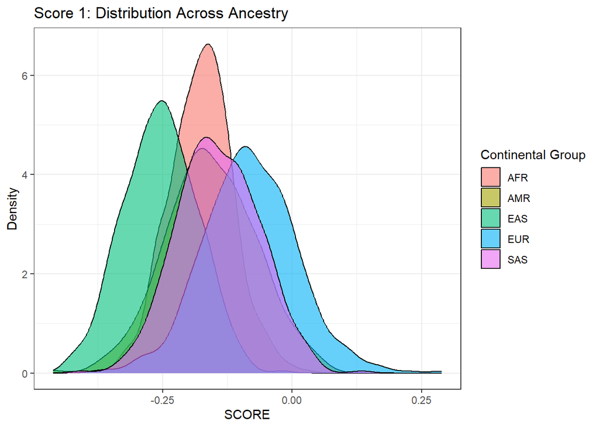

```r
# Create plot
ggplot(full, aes(x = score1, fill = Super_Population)) +
  geom_density(alpha = 0.6) +
  labs(title = "Score 1: Distribution Across Ancestry",
       x = "SCORE",
       y = "Density",
       fill = "Continental Group")
```

```r
# Save plot
ggsave("score1_1000g_bycontinent.png")
```

### Score Correlations with PCs

```r
for (score in scores) {
    lm <- lm(as.formula(paste0(score," ~ ", paste0(covars, collapse = " + "))), data = full)

    print(paste0("Model coefficients for: ", score))
    print(signif(summary(lm)[[4]], digits = 3))
}
```

```
## [1] "Model coefficients for: score1"
##              Estimate Std. Error t value  Pr(>|t|)
## (Intercept) -1.68e-01   6.51e-03 -25.900 5.17e-131
## sex          2.72e-03   2.99e-03   0.909  3.63e-01
## sim_age      1.49e-05   8.71e-05   0.171  8.64e-01
## PC1         -1.86e-01   7.54e-02  -2.470  1.37e-02
## PC2          2.90e+00   7.54e-02  38.400 3.55e-255
## PC3         -8.71e-02   7.54e-02  -1.150  2.48e-01
## PC4         -3.90e-01   7.54e-02  -5.170  2.50e-07
## PC5          9.85e-02   7.54e-02   1.310  1.92e-01
## [1] "Model coefficients for: score2"
##              Estimate Std. Error  t value  Pr(>|t|)
## (Intercept) -7.36e-01   0.009550 -77.1000  0.00e+00
## sex          1.06e-03   0.004390   0.2430  8.08e-01
## sim_age     -9.67e-05   0.000128  -0.7570  4.49e-01
## PC1          3.02e+00   0.111000  27.3000 3.05e-144
## PC2         -2.25e-01   0.111000  -2.0400  4.15e-02
## PC3         -2.96e-01   0.111000  -2.6800  7.38e-03
## PC4          2.25e-03   0.111000   0.0203  9.84e-01
## PC5          1.62e-01   0.111000   1.4600  1.44e-01
## [1] "Model coefficients for: score3"
##              Estimate Std. Error t value  Pr(>|t|)
## (Intercept)   0.30500   0.072900   4.180  2.97e-05
## sex           0.02310   0.033500   0.691  4.90e-01
## sim_age      -0.00024   0.000975  -0.246  8.06e-01
## PC1         154.00000   0.844000 183.000  0.00e+00
## PC2         -26.90000   0.844000 -31.900 5.62e-188
## PC3          -2.15000   0.844000  -2.540  1.10e-02
## PC4          -0.81300   0.844000  -0.963  3.36e-01
## PC5           2.85000   0.844000   3.370  7.50e-04
## [1] "Model coefficients for: score_sig"
##              Estimate Std. Error t value Pr(>|t|)
## (Intercept)  7.29e-02   3.49e-03  20.900 9.24e-90
## sex         -4.47e-04   1.60e-03  -0.279 7.80e-01
## sim_age     -4.49e-05   4.66e-05  -0.964 3.35e-01
## PC1         -5.43e-01   4.03e-02 -13.500 6.07e-40
## PC2          2.31e-01   4.04e-02   5.730 1.14e-08
## PC3         -3.77e-01   4.04e-02  -9.340 2.02e-20
## PC4          3.64e-02   4.04e-02   0.902 3.67e-01
## PC5         -5.23e-02   4.04e-02  -1.290 1.95e-01
## [1] "Model coefficients for: score_sug"
##              Estimate Std. Error t value Pr(>|t|)
## (Intercept)  5.62e-02   4.17e-03  13.500 4.57e-40
## sex         -4.43e-04   1.92e-03  -0.231 8.17e-01
## sim_age     -7.03e-05   5.58e-05  -1.260 2.07e-01
## PC1         -8.50e-01   4.83e-02 -17.600 1.71e-65
## PC2          2.19e-01   4.83e-02   4.530 6.26e-06
## PC3         -4.07e-01   4.83e-02  -8.430 5.84e-17
## PC4          9.21e-02   4.83e-02   1.910 5.66e-02
## PC5         -9.29e-02   4.83e-02  -1.920 5.46e-02
## [1] "Model coefficients for: score_inf"
##              Estimate Std. Error t value  Pr(>|t|)
## (Intercept) -0.880000   0.036200 -24.300 1.73e-117
## sex          0.010400   0.016600   0.624  5.33e-01
## sim_age      0.000283   0.000484   0.584  5.59e-01
## PC1         21.600000   0.419000  51.500  0.00e+00
## PC2         -0.833000   0.419000  -1.990  4.71e-02
## PC3          2.810000   0.419000   6.710  2.47e-11
## PC4         -1.350000   0.419000  -3.220  1.28e-03
## PC5          0.699000   0.420000   1.670  9.60e-02
```

### Ancestry Calibration

> *NOTE: the following method is similar to continuous ancestry calibration methods used by the NHGRI eMERGE Network and the PGS catalog. However, it should be used with caution as it is possible for the calibration to cancel out real genetic differences between groups that are important and informative*

Because scores often show confounding by ancestry, both in terms of score distribution and performance, we generally calibrate scores by genetic ancestry group. The following shows the calibration method for one score:

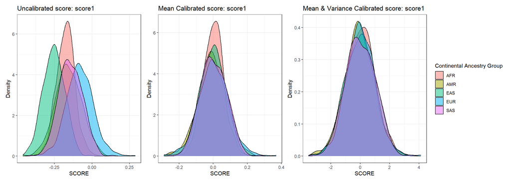

```r
# choose a score to look at, for example - score1
score <- "score1"

# step 1 - calibrate means
lm1 <- lm(as.formula(paste0(score," ~ ", paste0(pcs, collapse = " + "))), data = full)
full$calibrated1 <- full[[score]] - predict(lm1)

# step 2 - calibrate variances
resid_var <- (resid(lm1)-mean(resid(lm1)))^2
lm2 <- lm(as.formula(paste0("resid_var ~ ", paste0(pcs, collapse = " + "))), data = full)

predicted_var <- predict(lm2)

full$calibrated2 <- (full[[score]] - predict(lm1)) / sqrt(predicted_var)

# Plot calibrated scores for comparison

# Plot uncalibrated score
p1 <- ggplot(full, aes(x = .data[[score]], fill = Super_Population)) +
      geom_density(alpha = 0.5) +
      labs(title = paste0("Uncalibrated score: ", score),
           x = "SCORE",
           y = "Density",
           fill = "Continental Ancestry Group") +
      theme(legend.position = "none")

# Plot mean calibrated score
p2 <- ggplot(full, aes(x = calibrated1, fill = Super_Population)) +
      geom_density(alpha = 0.5) +
      labs(title = paste0("Mean Calibrated score: ", score),
           x = "SCORE",
           y = "Density",
           fill = "Continental Ancestry Group") +
      theme(legend.position = "none")

# Plot mean and variance calibrated score
p3 <- ggplot(full, aes(x = calibrated2, fill = Super_Population)) +
      geom_density(alpha = 0.5) +
      labs(title = paste0("Mean & Variance Calibrated score: ", score),
           x = "SCORE",
           y = "Density",
           fill = "Continental Ancestry Group")

# Make final combined plot for easy comparison
combined_plot <- p1 + p2 + p3

combined_plot
```

```r
# Save final plot
ggsave(paste0(score, "_ancestry_distributions_all.png"), width = 20, height = 5)
```